# Risk Factor Analysis

## Outcome Variable

**Outcome Variable:** wasted

## Predictor Variables

**Intervention Variable:** exclfeed36

**Adjustment Set:**

- arm
- sex
- brthmon
- W_mage
- meducyrs
- feducyrs
- hhwealth_quart
- hfoodsec
- W_mhtcm
- W_mwtkg
- W_mbmi
- vagbrth
- W_gagebrth
- W_birthwt
- W_birthlen
- W_nrooms
- W_nchldlt5
- month
- W_parity
- impfloor
- impsan
- safeh20
- delta_W_mage
- delta_meducyrs
- delta_feducyrs
- delta_hhwealth_quart
- delta_hfoodsec
- delta_W_mhtcm
- delta_W_mwtkg
- delta_W_mbmi
- delta_vagbrth
- delta_W_gagebrth
- delta_W_birthwt
- delta_W_birthlen
- delta_W_nrooms
- delta_W_nchldlt5
- delta_month
- delta_W_parity
- delta_impfloor
- delta_impsan
- delta_safeh20

## Stratifying Variables

The analysis was stratified on these variable(s):

- agecat
- studyid
- country

## Data Summary

| agecat | studyid | country | exclfeed36 | wasted | n_cell | n |
| --- | --- | --- | --- | --- | --- | --- |
| Birth | CMC-V-BCS-2002 | INDIA | 1 | 0 | 3 | 3 |
| Birth | CMC-V-BCS-2002 | INDIA | 1 | 1 | 0 | 3 |
| Birth | CMC-V-BCS-2002 | INDIA | 0 | 0 | 0 | 3 |
| Birth | CMC-V-BCS-2002 | INDIA | 0 | 1 | 0 | 3 |
| Birth | EE | PAKISTAN | 1 | 0 | 2 | 6 |
| Birth | EE | PAKISTAN | 1 | 1 | 0 | 6 |
| Birth | EE | PAKISTAN | 0 | 0 | 3 | 6 |
| Birth | EE | PAKISTAN | 0 | 1 | 1 | 6 |
| Birth | GMS-Nepal | NEPAL | 1 | 0 | 320 | 491 |
| Birth | GMS-Nepal | NEPAL | 1 | 1 | 76 | 491 |
| Birth | GMS-Nepal | NEPAL | 0 | 0 | 77 | 491 |
| Birth | GMS-Nepal | NEPAL | 0 | 1 | 18 | 491 |
| Birth | IRC | INDIA | 1 | 0 | 0 | 3 |
| Birth | IRC | INDIA | 1 | 1 | 0 | 3 |
| Birth | IRC | INDIA | 0 | 0 | 2 | 3 |
| Birth | IRC | INDIA | 0 | 1 | 1 | 3 |
| Birth | JiVitA-3 | BANGLADESH | 1 | 0 | 5974 | 8619 |
| Birth | JiVitA-3 | BANGLADESH | 1 | 1 | 762 | 8619 |
| Birth | JiVitA-3 | BANGLADESH | 0 | 0 | 1689 | 8619 |
| Birth | JiVitA-3 | BANGLADESH | 0 | 1 | 194 | 8619 |
| Birth | JiVitA-4 | BANGLADESH | 1 | 0 | 1537 | 2128 |
| Birth | JiVitA-4 | BANGLADESH | 1 | 1 | 174 | 2128 |
| Birth | JiVitA-4 | BANGLADESH | 0 | 0 | 370 | 2128 |
| Birth | JiVitA-4 | BANGLADESH | 0 | 1 | 47 | 2128 |
| Birth | Keneba | GAMBIA | 1 | 0 | 267 | 1192 |
| Birth | Keneba | GAMBIA | 1 | 1 | 76 | 1192 |
| Birth | Keneba | GAMBIA | 0 | 0 | 622 | 1192 |
| Birth | Keneba | GAMBIA | 0 | 1 | 227 | 1192 |
| Birth | MAL-ED | BANGLADESH | 1 | 0 | 27 | 208 |
| Birth | MAL-ED | BANGLADESH | 1 | 1 | 4 | 208 |

[output cut: 162 more lines]

The following strata were considered:

- agecat: 24 months, studyid: CMC-V-BCS-2002, country: INDIA
- agecat: 24 months, studyid: EE, country: PAKISTAN
- agecat: 24 months, studyid: GMS-Nepal, country: NEPAL
- agecat: 24 months, studyid: IRC, country: INDIA
- agecat: 24 months, studyid: JiVitA-3, country: BANGLADESH
- agecat: 24 months, studyid: JiVitA-4, country: BANGLADESH
- agecat: 24 months, studyid: Keneba, country: GAMBIA
- agecat: 24 months, studyid: LCNI-5, country: MALAWI
- agecat: 24 months, studyid: MAL-ED, country: BANGLADESH
- agecat: 24 months, studyid: MAL-ED, country: BRAZIL
- agecat: 24 months, studyid: MAL-ED, country: INDIA
- agecat: 24 months, studyid: MAL-ED, country: NEPAL
- agecat: 24 months, studyid: MAL-ED, country: PERU
- agecat: 24 months, studyid: MAL-ED, country: SOUTH AFRICA
- agecat: 24 months, studyid: MAL-ED, country: TANZANIA, UNITED REPUBLIC OF
- agecat: 24 months, studyid: PROVIDE, country: BANGLADESH
- agecat: 6 months, studyid: CMC-V-BCS-2002, country: INDIA
- agecat: 6 months, studyid: EE, country: PAKISTAN
- agecat: 6 months, studyid: GMS-Nepal, country: NEPAL
- agecat: 6 months, studyid: IRC, country: INDIA
- agecat: 6 months, studyid: JiVitA-3, country: BANGLADESH
- agecat: 6 months, studyid: JiVitA-4, country: BANGLADESH
- agecat: 6 months, studyid: Keneba, country: GAMBIA
- agecat: 6 months, studyid: LCNI-5, country: MALAWI
- agecat: 6 months, studyid: MAL-ED, country: BANGLADESH
- agecat: 6 months, studyid: MAL-ED, country: BRAZIL
- agecat: 6 months, studyid: MAL-ED, country: INDIA
- agecat: 6 months, studyid: MAL-ED, country: NEPAL
- agecat: 6 months, studyid: MAL-ED, country: PERU
- agecat: 6 months, studyid: MAL-ED, country: SOUTH AFRICA
- agecat: 6 months, studyid: MAL-ED, country: TANZANIA, UNITED REPUBLIC OF
- agecat: 6 months, studyid: PROVIDE, country: BANGLADESH
- agecat: 6 months, studyid: SAS-FoodSuppl, country: INDIA
- agecat: Birth, studyid: CMC-V-BCS-2002, country: INDIA
- agecat: Birth, studyid: EE, country: PAKISTAN
- agecat: Birth, studyid: GMS-Nepal, country: NEPAL
- agecat: Birth, studyid: IRC, country: INDIA
- agecat: Birth, studyid: JiVitA-3, country: BANGLADESH
- agecat: Birth, studyid: JiVitA-4, country: BANGLADESH
- agecat: Birth, studyid: Keneba, country: GAMBIA
- agecat: Birth, studyid: MAL-ED, country: BANGLADESH
- agecat: Birth, studyid: MAL-ED, country: BRAZIL
- agecat: Birth, studyid: MAL-ED, country: INDIA
- agecat: Birth, studyid: MAL-ED, country: NEPAL
- agecat: Birth, studyid: MAL-ED, country: PERU
- agecat: Birth, studyid: MAL-ED, country: SOUTH AFRICA
- agecat: Birth, studyid: MAL-ED, country: TANZANIA, UNITED REPUBLIC OF
- agecat: Birth, studyid: PROVIDE, country: BANGLADESH

### Dropped Strata

Some strata were dropped due to rare outcomes:

- agecat: Birth, studyid: CMC-V-BCS-2002, country: INDIA
- agecat: Birth, studyid: EE, country: PAKISTAN
- agecat: Birth, studyid: IRC, country: INDIA
- agecat: Birth, studyid: MAL-ED, country: BANGLADESH
- agecat: Birth, studyid: MAL-ED, country: BRAZIL
- agecat: Birth, studyid: MAL-ED, country: INDIA
- agecat: Birth, studyid: MAL-ED, country: NEPAL
- agecat: Birth, studyid: MAL-ED, country: PERU
- agecat: Birth, studyid: MAL-ED, country: SOUTH AFRICA
- agecat: Birth, studyid: MAL-ED, country: TANZANIA, UNITED REPUBLIC OF
- agecat: 6 months, studyid: CMC-V-BCS-2002, country: INDIA
- agecat: 6 months, studyid: EE, country: PAKISTAN
- agecat: 6 months, studyid: IRC, country: INDIA
- agecat: 6 months, studyid: LCNI-5, country: MALAWI
- agecat: 6 months, studyid: MAL-ED, country: BANGLADESH
- agecat: 6 months, studyid: MAL-ED, country: BRAZIL
- agecat: 6 months, studyid: MAL-ED, country: INDIA
- agecat: 6 months, studyid: MAL-ED, country: NEPAL
- agecat: 6 months, studyid: MAL-ED, country: PERU
- agecat: 6 months, studyid: MAL-ED, country: SOUTH AFRICA
- agecat: 6 months, studyid: MAL-ED, country: TANZANIA, UNITED REPUBLIC OF
- agecat: 6 months, studyid: PROVIDE, country: BANGLADESH
- agecat: 6 months, studyid: SAS-FoodSuppl, country: INDIA
- agecat: 24 months, studyid: CMC-V-BCS-2002, country: INDIA
- agecat: 24 months, studyid: EE, country: PAKISTAN
- agecat: 24 months, studyid: IRC, country: INDIA
- agecat: 24 months, studyid: LCNI-5, country: MALAWI
- agecat: 24 months, studyid: MAL-ED, country: BANGLADESH
- agecat: 24 months, studyid: MAL-ED, country: BRAZIL
- agecat: 24 months, studyid: MAL-ED, country: INDIA
- agecat: 24 months, studyid: MAL-ED, country: NEPAL
- agecat: 24 months, studyid: MAL-ED, country: PERU
- agecat: 24 months, studyid: MAL-ED, country: SOUTH AFRICA
- agecat: 24 months, studyid: MAL-ED, country: TANZANIA, UNITED REPUBLIC OF

## Methods Detail

We’re interested in the causal parameters $E[Y_a]$ for all values of $a \in \mathcal{A}$. These parameters represent the mean outcome if, possibly contrary to fact, we intervened to set all units to have $A=a$. Under the randomization and positivity assumptions, these are identified by the statistical parameters $\psi_a=E_W[E_{Y|A,W}(Y|A=a,W)]$. In addition, we’re interested in the mean of $Y$, $E[Y]$ under no intervention (the observed mean). We will estimate these parameters by using SuperLearner to fit the relevant likelihood factors – $E_{Y|A,W}(Y|A=a,W)$ and $p(A=a|W)$, and then updating our likelihood fit using a joint TMLE.

For unadjusted analyses ($W=\{\}$), initial likelihoods were estimated using Lrnr_glm to estimate the simple $E(Y|A)$ and Lrnr_mean to estimate $p(A)$. For adjusted analyses, a small library containing Lrnr_glmnet, Lrnr_xgboost, and Lrnr_mean was used.

Having estimated these parameters, we will then use the delta method to estimate relative risks and attributable risks relative to a prespecified baseline level of $A$.

# Results Detail

## Results Plots

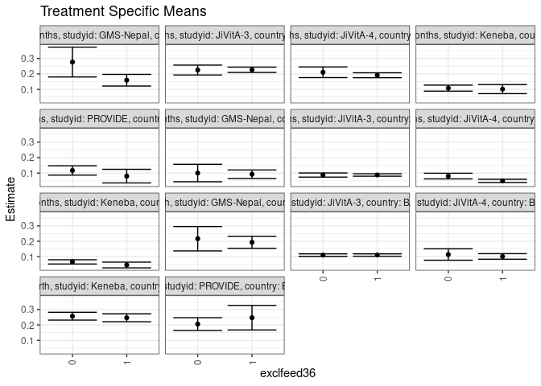

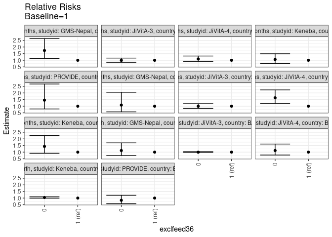

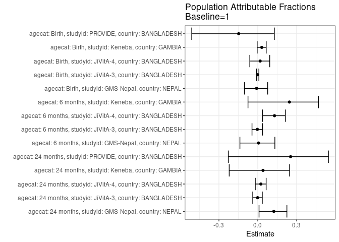

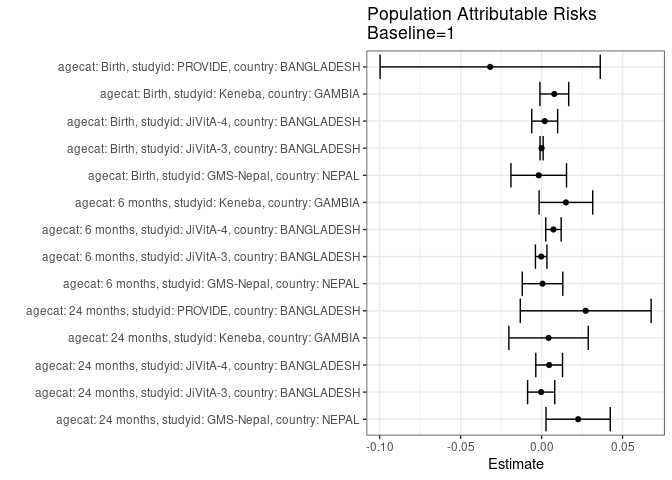

## Results Table

### Parameter: TSM

| agecat | studyid | country | intervention_level | baseline_level | estimate | ci_lower | ci_upper |
| --- | --- | --- | --- | --- | --- | --- | --- |
| Birth | GMS-Nepal | NEPAL | 1 | NA | 0.1932257 | 0.1543980 | 0.2320534 |
| Birth | GMS-Nepal | NEPAL | 0 | NA | 0.2166617 | 0.1378508 | 0.2954726 |
| Birth | JiVitA-3 | BANGLADESH | 1 | NA | 0.1109306 | 0.1032764 | 0.1185848 |
| Birth | JiVitA-3 | BANGLADESH | 0 | NA | 0.1104540 | 0.1023523 | 0.1185558 |
| Birth | JiVitA-4 | BANGLADESH | 1 | NA | 0.1019411 | 0.0839861 | 0.1198962 |
| Birth | JiVitA-4 | BANGLADESH | 0 | NA | 0.1143150 | 0.0773736 | 0.1512564 |
| Birth | Keneba | GAMBIA | 1 | NA | 0.2463511 | 0.2207981 | 0.2719041 |
| Birth | Keneba | GAMBIA | 0 | NA | 0.2566784 | 0.2314484 | 0.2819083 |
| Birth | PROVIDE | BANGLADESH | 1 | NA | 0.2470821 | 0.1676240 | 0.3265402 |
| Birth | PROVIDE | BANGLADESH | 0 | NA | 0.2055163 | 0.1644105 | 0.2466221 |
| 6 months | GMS-Nepal | NEPAL | 1 | NA | 0.0924085 | 0.0648079 | 0.1200091 |
| 6 months | GMS-Nepal | NEPAL | 0 | NA | 0.1002134 | 0.0438216 | 0.1566052 |
| 6 months | JiVitA-3 | BANGLADESH | 1 | NA | 0.0875501 | 0.0798067 | 0.0952935 |
| 6 months | JiVitA-3 | BANGLADESH | 0 | NA | 0.0871521 | 0.0738188 | 0.1004854 |
| 6 months | JiVitA-4 | BANGLADESH | 1 | NA | 0.0492792 | 0.0388047 | 0.0597537 |
| 6 months | JiVitA-4 | BANGLADESH | 0 | NA | 0.0805109 | 0.0621914 | 0.0988304 |
| 6 months | Keneba | GAMBIA | 1 | NA | 0.0464423 | 0.0278634 | 0.0650211 |
| 6 months | Keneba | GAMBIA | 0 | NA | 0.0665590 | 0.0528747 | 0.0802433 |
| 24 months | GMS-Nepal | NEPAL | 1 | NA | 0.1594681 | 0.1216871 | 0.1972491 |
| 24 months | GMS-Nepal | NEPAL | 0 | NA | 0.2770481 | 0.1805882 | 0.3735080 |
| 24 months | JiVitA-3 | BANGLADESH | 1 | NA | 0.2270519 | 0.2097390 | 0.2443648 |
| 24 months | JiVitA-3 | BANGLADESH | 0 | NA | 0.2253246 | 0.1934530 | 0.2571962 |
| 24 months | JiVitA-4 | BANGLADESH | 1 | NA | 0.1916249 | 0.1755650 | 0.2076848 |
| 24 months | JiVitA-4 | BANGLADESH | 0 | NA | 0.2108712 | 0.1764301 | 0.2453123 |
| 24 months | Keneba | GAMBIA | 1 | NA | 0.1018027 | 0.0725455 | 0.1310600 |
| 24 months | Keneba | GAMBIA | 0 | NA | 0.1081677 | 0.0887395 | 0.1275959 |
| 24 months | PROVIDE | BANGLADESH | 1 | NA | 0.0802156 | 0.0360560 | 0.1243751 |
| 24 months | PROVIDE | BANGLADESH | 0 | NA | 0.1168589 | 0.0866005 | 0.1471174 |

### Parameter: E(Y)

| agecat | studyid | country | intervention_level | baseline_level | estimate | ci_lower | ci_upper |
| --- | --- | --- | --- | --- | --- | --- | --- |
| Birth | GMS-Nepal | NEPAL | NA | NA | 0.1914460 | 0.1566101 | 0.2262820 |
| Birth | JiVitA-3 | BANGLADESH | NA | NA | 0.1109177 | 0.1033745 | 0.1184610 |
| Birth | JiVitA-4 | BANGLADESH | NA | NA | 0.1038534 | 0.0874500 | 0.1202568 |
| Birth | Keneba | GAMBIA | NA | NA | 0.2541946 | 0.2294667 | 0.2789226 |
| Birth | PROVIDE | BANGLADESH | NA | NA | 0.2153209 | 0.1786253 | 0.2520165 |
| 6 months | GMS-Nepal | NEPAL | NA | NA | 0.0929791 | 0.0681617 | 0.1177965 |
| 6 months | JiVitA-3 | BANGLADESH | NA | NA | 0.0872876 | 0.0805483 | 0.0940269 |
| 6 months | JiVitA-4 | BANGLADESH | NA | NA | 0.0565903 | 0.0475372 | 0.0656433 |
| 6 months | Keneba | GAMBIA | NA | NA | 0.0614525 | 0.0503239 | 0.0725811 |
| 24 months | GMS-Nepal | NEPAL | NA | NA | 0.1820225 | 0.1461311 | 0.2179138 |
| 24 months | JiVitA-3 | BANGLADESH | NA | NA | 0.2267779 | 0.2114523 | 0.2421034 |
| 24 months | JiVitA-4 | BANGLADESH | NA | NA | 0.1962825 | 0.1816413 | 0.2109237 |
| 24 months | Keneba | GAMBIA | NA | NA | 0.1060932 | 0.0899270 | 0.1222593 |
| 24 months | PROVIDE | BANGLADESH | NA | NA | 0.1074523 | 0.0821617 | 0.1327430 |

### Parameter: RR

| agecat | studyid | country | intervention_level | baseline_level | estimate | ci_lower | ci_upper |
| --- | --- | --- | --- | --- | --- | --- | --- |
| Birth | GMS-Nepal | NEPAL | 1 | 1 | 1.0000000 | 1.0000000 | 1.000000 |
| Birth | GMS-Nepal | NEPAL | 0 | 1 | 1.1212885 | 0.7391773 | 1.700929 |
| Birth | JiVitA-3 | BANGLADESH | 1 | 1 | 1.0000000 | 1.0000000 | 1.000000 |
| Birth | JiVitA-3 | BANGLADESH | 0 | 1 | 0.9957040 | 0.9569005 | 1.036081 |
| Birth | JiVitA-4 | BANGLADESH | 1 | 1 | 1.0000000 | 1.0000000 | 1.000000 |
| Birth | JiVitA-4 | BANGLADESH | 0 | 1 | 1.1213824 | 0.7802234 | 1.611716 |
| Birth | Keneba | GAMBIA | 1 | 1 | 1.0000000 | 1.0000000 | 1.000000 |
| Birth | Keneba | GAMBIA | 0 | 1 | 1.0419210 | 0.9917087 | 1.094676 |
| Birth | PROVIDE | BANGLADESH | 1 | 1 | 1.0000000 | 1.0000000 | 1.000000 |
| Birth | PROVIDE | BANGLADESH | 0 | 1 | 0.8317732 | 0.5709055 | 1.211841 |
| 6 months | GMS-Nepal | NEPAL | 1 | 1 | 1.0000000 | 1.0000000 | 1.000000 |
| 6 months | GMS-Nepal | NEPAL | 0 | 1 | 1.0844614 | 0.5727413 | 2.053382 |
| 6 months | JiVitA-3 | BANGLADESH | 1 | 1 | 1.0000000 | 1.0000000 | 1.000000 |
| 6 months | JiVitA-3 | BANGLADESH | 0 | 1 | 0.9954540 | 0.8350176 | 1.186716 |
| 6 months | JiVitA-4 | BANGLADESH | 1 | 1 | 1.0000000 | 1.0000000 | 1.000000 |
| 6 months | JiVitA-4 | BANGLADESH | 0 | 1 | 1.6337714 | 1.1963141 | 2.231194 |
| 6 months | Keneba | GAMBIA | 1 | 1 | 1.0000000 | 1.0000000 | 1.000000 |
| 6 months | Keneba | GAMBIA | 0 | 1 | 1.4331559 | 0.9144138 | 2.246178 |
| 24 months | GMS-Nepal | NEPAL | 1 | 1 | 1.0000000 | 1.0000000 | 1.000000 |
| 24 months | GMS-Nepal | NEPAL | 0 | 1 | 1.7373261 | 1.1421879 | 2.642562 |
| 24 months | JiVitA-3 | BANGLADESH | 1 | 1 | 1.0000000 | 1.0000000 | 1.000000 |
| 24 months | JiVitA-3 | BANGLADESH | 0 | 1 | 0.9923925 | 0.8462322 | 1.163798 |
| 24 months | JiVitA-4 | BANGLADESH | 1 | 1 | 1.0000000 | 1.0000000 | 1.000000 |
| 24 months | JiVitA-4 | BANGLADESH | 0 | 1 | 1.1004374 | 0.9179442 | 1.319211 |
| 24 months | Keneba | GAMBIA | 1 | 1 | 1.0000000 | 1.0000000 | 1.000000 |
| 24 months | Keneba | GAMBIA | 0 | 1 | 1.0625221 | 0.7577328 | 1.489909 |
| 24 months | PROVIDE | BANGLADESH | 1 | 1 | 1.0000000 | 1.0000000 | 1.000000 |
| 24 months | PROVIDE | BANGLADESH | 0 | 1 | 1.4568115 | 0.7931362 | 2.675833 |

### Parameter: PAR

| agecat | studyid | country | intervention_level | baseline_level | estimate | ci_lower | ci_upper |
| --- | --- | --- | --- | --- | --- | --- | --- |
| Birth | GMS-Nepal | NEPAL | 1 | NA | -0.0017797 | -0.0189367 | 0.0153774 |
| Birth | JiVitA-3 | BANGLADESH | 1 | NA | -0.0000129 | -0.0009755 | 0.0009498 |
| Birth | JiVitA-4 | BANGLADESH | 1 | NA | 0.0019122 | -0.0060762 | 0.0099006 |
| Birth | Keneba | GAMBIA | 1 | NA | 0.0078435 | -0.0010391 | 0.0167261 |
| Birth | PROVIDE | BANGLADESH | 1 | NA | -0.0317612 | -0.0997435 | 0.0362211 |
| 6 months | GMS-Nepal | NEPAL | 1 | NA | 0.0005706 | -0.0119412 | 0.0130825 |
| 6 months | JiVitA-3 | BANGLADESH | 1 | NA | -0.0002625 | -0.0038168 | 0.0032918 |
| 6 months | JiVitA-4 | BANGLADESH | 1 | NA | 0.0073111 | 0.0025503 | 0.0120719 |
| 6 months | Keneba | GAMBIA | 1 | NA | 0.0150103 | -0.0015438 | 0.0315643 |
| 24 months | GMS-Nepal | NEPAL | 1 | NA | 0.0225544 | 0.0027220 | 0.0423867 |
| 24 months | JiVitA-3 | BANGLADESH | 1 | NA | -0.0002740 | -0.0086488 | 0.0081007 |
| 24 months | JiVitA-4 | BANGLADESH | 1 | NA | 0.0046576 | -0.0035915 | 0.0129068 |
| 24 months | Keneba | GAMBIA | 1 | NA | 0.0042905 | -0.0202052 | 0.0287861 |
| 24 months | PROVIDE | BANGLADESH | 1 | NA | 0.0272368 | -0.0131641 | 0.0676376 |

### Parameter: PAF

| agecat | studyid | country | intervention_level | baseline_level | estimate | ci_lower | ci_upper |
| --- | --- | --- | --- | --- | --- | --- | --- |
| Birth | GMS-Nepal | NEPAL | 1 | NA | -0.0092959 | -0.1030311 | 0.0764738 |
| Birth | JiVitA-3 | BANGLADESH | 1 | NA | -0.0001159 | -0.0088325 | 0.0085253 |
| Birth | JiVitA-4 | BANGLADESH | 1 | NA | 0.0184129 | -0.0615346 | 0.0923393 |
| Birth | Keneba | GAMBIA | 1 | NA | 0.0308564 | -0.0045936 | 0.0650554 |
| Birth | PROVIDE | BANGLADESH | 1 | NA | -0.1475063 | -0.5099648 | 0.1279461 |
| 6 months | GMS-Nepal | NEPAL | 1 | NA | 0.0061374 | -0.1379435 | 0.1319754 |
| 6 months | JiVitA-3 | BANGLADESH | 1 | NA | -0.0030072 | -0.0445554 | 0.0368883 |
| 6 months | JiVitA-4 | BANGLADESH | 1 | NA | 0.1291931 | 0.0368067 | 0.2127180 |
| 6 months | Keneba | GAMBIA | 1 | NA | 0.2442578 | -0.0755184 | 0.4689572 |
| 24 months | GMS-Nepal | NEPAL | 1 | NA | 0.1239098 | 0.0097377 | 0.2249185 |
| 24 months | JiVitA-3 | BANGLADESH | 1 | NA | -0.0012084 | -0.0388291 | 0.0350499 |
| 24 months | JiVitA-4 | BANGLADESH | 1 | NA | 0.0237292 | -0.0190668 | 0.0647279 |
| 24 months | Keneba | GAMBIA | 1 | NA | 0.0404404 | -0.2206461 | 0.2456825 |
| 24 months | PROVIDE | BANGLADESH | 1 | NA | 0.2534778 | -0.2275751 | 0.5460193 |